# Risk Factor Analysis

## Outcome Variable

**Outcome Variable:** haz

## Predictor Variables

**Intervention Variable:** pers_wast

**Adjustment Set:**

unadjusted

## Stratifying Variables

The analysis was stratified on these variable(s):

- agecat
- studyid
- country

## Data Summary

| agecat | studyid | country | pers_wast | n_cell | n |
| --- | --- | --- | --- | --- | --- |
| Birth | ki0047075b-MAL-ED | BANGLADESH | 0 | 246 | 255 |
| Birth | ki0047075b-MAL-ED | BANGLADESH | 1 | 9 | 255 |
| Birth | ki0047075b-MAL-ED | BRAZIL | 0 | 191 | 191 |
| Birth | ki0047075b-MAL-ED | BRAZIL | 1 | 0 | 191 |
| Birth | ki0047075b-MAL-ED | INDIA | 0 | 191 | 206 |
| Birth | ki0047075b-MAL-ED | INDIA | 1 | 15 | 206 |
| Birth | ki0047075b-MAL-ED | NEPAL | 0 | 170 | 173 |
| Birth | ki0047075b-MAL-ED | NEPAL | 1 | 3 | 173 |
| Birth | ki0047075b-MAL-ED | PERU | 0 | 286 | 286 |
| Birth | ki0047075b-MAL-ED | PERU | 1 | 0 | 286 |
| Birth | ki0047075b-MAL-ED | SOUTH AFRICA | 0 | 255 | 261 |
| Birth | ki0047075b-MAL-ED | SOUTH AFRICA | 1 | 6 | 261 |
| Birth | ki0047075b-MAL-ED | TANZANIA, UNITED REPUBLIC OF | 0 | 123 | 123 |
| Birth | ki0047075b-MAL-ED | TANZANIA, UNITED REPUBLIC OF | 1 | 0 | 123 |
| Birth | ki1000108-CMC-V-BCS-2002 | INDIA | 0 | 78 | 90 |
| Birth | ki1000108-CMC-V-BCS-2002 | INDIA | 1 | 12 | 90 |
| Birth | ki1000108-IRC | INDIA | 0 | 319 | 388 |
| Birth | ki1000108-IRC | INDIA | 1 | 69 | 388 |
| Birth | ki1000109-EE | PAKISTAN | 0 | 2 | 2 |
| Birth | ki1000109-EE | PAKISTAN | 1 | 0 | 2 |
| Birth | ki1000109-ResPak | PAKISTAN | 0 | 6 | 7 |
| Birth | ki1000109-ResPak | PAKISTAN | 1 | 1 | 7 |
| Birth | ki1101329-Keneba | GAMBIA | 0 | 1507 | 1541 |
| Birth | ki1101329-Keneba | GAMBIA | 1 | 34 | 1541 |
| Birth | ki1114097-CMIN | BANGLADESH | 0 | 5 | 8 |
| Birth | ki1114097-CMIN | BANGLADESH | 1 | 3 | 8 |
| Birth | ki1114097-CMIN | PERU | 0 | 10 | 10 |
| Birth | ki1114097-CMIN | PERU | 1 | 0 | 10 |
| Birth | ki1114097-CONTENT | PERU | 0 | 2 | 2 |
| Birth | ki1114097-CONTENT | PERU | 1 | 0 | 2 |

[output cut: 70 more lines]

The following strata were considered:

- agecat: 24 months, studyid: ki0047075b-MAL-ED, country: BANGLADESH
- agecat: 24 months, studyid: ki0047075b-MAL-ED, country: BRAZIL
- agecat: 24 months, studyid: ki0047075b-MAL-ED, country: INDIA
- agecat: 24 months, studyid: ki0047075b-MAL-ED, country: NEPAL
- agecat: 24 months, studyid: ki0047075b-MAL-ED, country: PERU
- agecat: 24 months, studyid: ki0047075b-MAL-ED, country: SOUTH AFRICA
- agecat: 24 months, studyid: ki0047075b-MAL-ED, country: TANZANIA, UNITED REPUBLIC OF
- agecat: 24 months, studyid: ki1000108-CMC-V-BCS-2002, country: INDIA
- agecat: 24 months, studyid: ki1000108-IRC, country: INDIA
- agecat: 24 months, studyid: ki1017093b-PROVIDE, country: BANGLADESH
- agecat: 24 months, studyid: ki1066203-TanzaniaChild2, country: TANZANIA, UNITED REPUBLIC OF
- agecat: 24 months, studyid: ki1101329-Keneba, country: GAMBIA
- agecat: 24 months, studyid: ki1113344-GMS-Nepal, country: NEPAL
- agecat: 24 months, studyid: ki1114097-CMIN, country: BANGLADESH
- agecat: 24 months, studyid: ki1114097-CMIN, country: PERU
- agecat: 24 months, studyid: ki1114097-CONTENT, country: PERU
- agecat: 6 months, studyid: ki0047075b-MAL-ED, country: BANGLADESH
- agecat: 6 months, studyid: ki0047075b-MAL-ED, country: BRAZIL
- agecat: 6 months, studyid: ki0047075b-MAL-ED, country: INDIA
- agecat: 6 months, studyid: ki0047075b-MAL-ED, country: NEPAL
- agecat: 6 months, studyid: ki0047075b-MAL-ED, country: PERU
- agecat: 6 months, studyid: ki0047075b-MAL-ED, country: SOUTH AFRICA
- agecat: 6 months, studyid: ki0047075b-MAL-ED, country: TANZANIA, UNITED REPUBLIC OF
- agecat: 6 months, studyid: ki1000108-CMC-V-BCS-2002, country: INDIA
- agecat: 6 months, studyid: ki1000108-IRC, country: INDIA
- agecat: 6 months, studyid: ki1000109-EE, country: PAKISTAN
- agecat: 6 months, studyid: ki1000109-ResPak, country: PAKISTAN
- agecat: 6 months, studyid: ki1017093b-PROVIDE, country: BANGLADESH
- agecat: 6 months, studyid: ki1066203-TanzaniaChild2, country: TANZANIA, UNITED REPUBLIC OF
- agecat: 6 months, studyid: ki1101329-Keneba, country: GAMBIA
- agecat: 6 months, studyid: ki1112895-Guatemala BSC, country: GUATEMALA
- agecat: 6 months, studyid: ki1113344-GMS-Nepal, country: NEPAL
- agecat: 6 months, studyid: ki1114097-CMIN, country: BANGLADESH
- agecat: 6 months, studyid: ki1114097-CMIN, country: PERU
- agecat: 6 months, studyid: ki1114097-CONTENT, country: PERU
- agecat: Birth, studyid: ki0047075b-MAL-ED, country: BANGLADESH
- agecat: Birth, studyid: ki0047075b-MAL-ED, country: BRAZIL
- agecat: Birth, studyid: ki0047075b-MAL-ED, country: INDIA
- agecat: Birth, studyid: ki0047075b-MAL-ED, country: NEPAL
- agecat: Birth, studyid: ki0047075b-MAL-ED, country: PERU
- agecat: Birth, studyid: ki0047075b-MAL-ED, country: SOUTH AFRICA
- agecat: Birth, studyid: ki0047075b-MAL-ED, country: TANZANIA, UNITED REPUBLIC OF
- agecat: Birth, studyid: ki1000108-CMC-V-BCS-2002, country: INDIA
- agecat: Birth, studyid: ki1000108-IRC, country: INDIA
- agecat: Birth, studyid: ki1000109-EE, country: PAKISTAN
- agecat: Birth, studyid: ki1000109-ResPak, country: PAKISTAN
- agecat: Birth, studyid: ki1101329-Keneba, country: GAMBIA
- agecat: Birth, studyid: ki1114097-CMIN, country: BANGLADESH
- agecat: Birth, studyid: ki1114097-CMIN, country: PERU
- agecat: Birth, studyid: ki1114097-CONTENT, country: PERU

### Dropped Strata

Some strata were dropped due to rare outcomes:

- agecat: Birth, studyid: ki0047075b-MAL-ED, country: BRAZIL
- agecat: Birth, studyid: ki0047075b-MAL-ED, country: NEPAL
- agecat: Birth, studyid: ki0047075b-MAL-ED, country: PERU
- agecat: Birth, studyid: ki0047075b-MAL-ED, country: TANZANIA, UNITED REPUBLIC OF
- agecat: Birth, studyid: ki1000109-EE, country: PAKISTAN
- agecat: Birth, studyid: ki1000109-ResPak, country: PAKISTAN
- agecat: Birth, studyid: ki1114097-CMIN, country: BANGLADESH
- agecat: Birth, studyid: ki1114097-CMIN, country: PERU
- agecat: Birth, studyid: ki1114097-CONTENT, country: PERU
- agecat: 6 months, studyid: ki0047075b-MAL-ED, country: BRAZIL
- agecat: 6 months, studyid: ki0047075b-MAL-ED, country: NEPAL
- agecat: 6 months, studyid: ki0047075b-MAL-ED, country: PERU
- agecat: 6 months, studyid: ki0047075b-MAL-ED, country: SOUTH AFRICA
- agecat: 6 months, studyid: ki0047075b-MAL-ED, country: TANZANIA, UNITED REPUBLIC OF
- agecat: 6 months, studyid: ki1114097-CONTENT, country: PERU
- agecat: 24 months, studyid: ki0047075b-MAL-ED, country: BRAZIL
- agecat: 24 months, studyid: ki0047075b-MAL-ED, country: NEPAL
- agecat: 24 months, studyid: ki0047075b-MAL-ED, country: PERU
- agecat: 24 months, studyid: ki0047075b-MAL-ED, country: SOUTH AFRICA
- agecat: 24 months, studyid: ki0047075b-MAL-ED, country: TANZANIA, UNITED REPUBLIC OF
- agecat: 24 months, studyid: ki1066203-TanzaniaChild2, country: TANZANIA, UNITED REPUBLIC OF
- agecat: 24 months, studyid: ki1114097-CONTENT, country: PERU

## Methods Detail

We’re interested in the causal parameters $E[Y_a]$ for all values of $a \in \mathcal{A}$. These parameters represent the mean outcome if, possibly contrary to fact, we intervened to set all units to have $A=a$. Under the randomization and positivity assumptions, these are identified by the statistical parameters $\psi_a=E_W[E_{Y|A,W}(Y|A=a,W)]$. In addition, we’re interested in the mean of $Y$, $E[Y]$ under no intervention (the observed mean). We will estimate these parameters by using SuperLearner to fit the relevant likelihood factors – $E_{Y|A,W}(Y|A=a,W)$ and $p(A=a|W)$, and then updating our likelihood fit using a joint TMLE.

For unadjusted analyses ($W=\{\}$), initial likelihoods were estimated using Lrnr_glm to estimate the simple $E(Y|A)$ and Lrnr_mean to estimate $p(A)$. For adjusted analyses, a small library containing Lrnr_glmnet, Lrnr_xgboost, and Lrnr_mean was used.

Having estimated these parameters, we will then use the delta method to estimate relative risks and attributable risks relative to a prespecified baseline level of $A$.

# Results Detail

## Results Plots

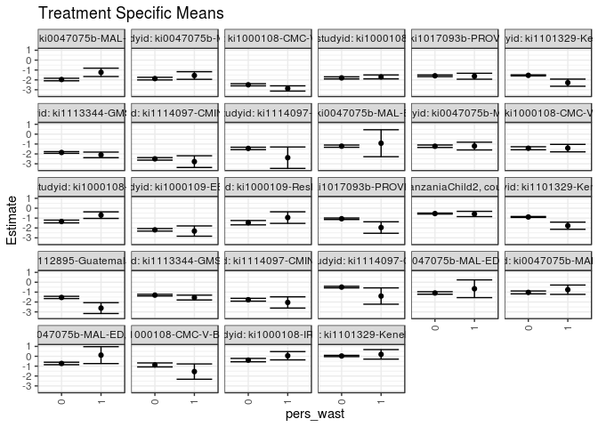

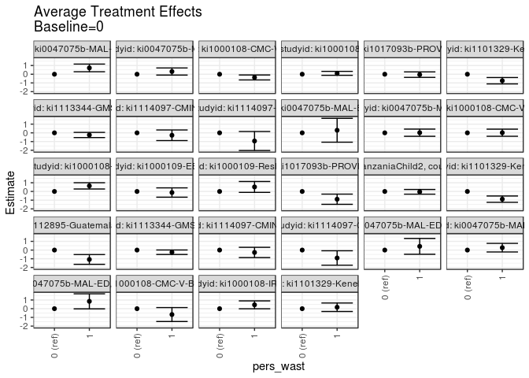

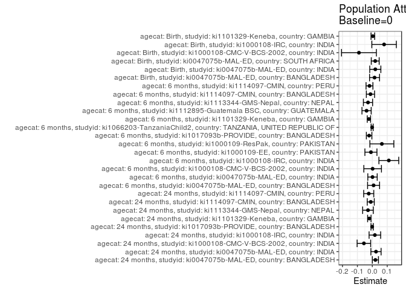

## Results Table

### Parameter: TSM

| agecat | studyid | country | intervention_level | baseline_level | estimate | ci_lower | ci_upper |
| --- | --- | --- | --- | --- | --- | --- | --- |
| Birth | ki0047075b-MAL-ED | BANGLADESH | 0 | NA | -1.0866260 | -1.2119716 | -0.9612804 |
| Birth | ki0047075b-MAL-ED | BANGLADESH | 1 | NA | -0.6600000 | -1.5590083 | 0.2390083 |
| Birth | ki0047075b-MAL-ED | INDIA | 0 | NA | -1.0307330 | -1.1760304 | -0.8854356 |
| Birth | ki0047075b-MAL-ED | INDIA | 1 | NA | -0.7546667 | -1.2259050 | -0.2834283 |
| Birth | ki0047075b-MAL-ED | SOUTH AFRICA | 0 | NA | -0.7258431 | -0.8486531 | -0.6030332 |
| Birth | ki0047075b-MAL-ED | SOUTH AFRICA | 1 | NA | 0.1183333 | -0.7367533 | 0.9734200 |
| Birth | ki1000108-CMC-V-BCS-2002 | INDIA | 0 | NA | -0.8758974 | -1.0779449 | -0.6738500 |
| Birth | ki1000108-CMC-V-BCS-2002 | INDIA | 1 | NA | -1.5475000 | -2.3222582 | -0.7727418 |
| Birth | ki1000108-IRC | INDIA | 0 | NA | -0.3869592 | -0.5590341 | -0.2148844 |
| Birth | ki1000108-IRC | INDIA | 1 | NA | 0.0568116 | -0.3617473 | 0.4753705 |
| Birth | ki1101329-Keneba | GAMBIA | 0 | NA | 0.0304910 | -0.0334767 | 0.0944588 |
| Birth | ki1101329-Keneba | GAMBIA | 1 | NA | 0.1961765 | -0.2865666 | 0.6789195 |
| 6 months | ki0047075b-MAL-ED | BANGLADESH | 0 | NA | -1.2142877 | -1.3279958 | -1.1005797 |
| 6 months | ki0047075b-MAL-ED | BANGLADESH | 1 | NA | -0.9178571 | -2.2823123 | 0.4465980 |
| 6 months | ki0047075b-MAL-ED | INDIA | 0 | NA | -1.2216820 | -1.3456583 | -1.0977056 |
| 6 months | ki0047075b-MAL-ED | INDIA | 1 | NA | -1.2044444 | -1.5982144 | -0.8106745 |
| 6 months | ki1000108-CMC-V-BCS-2002 | INDIA | 0 | NA | -1.4272790 | -1.5807610 | -1.2737971 |
| 6 months | ki1000108-CMC-V-BCS-2002 | INDIA | 1 | NA | -1.4124528 | -1.7910692 | -1.0338364 |
| 6 months | ki1000108-IRC | INDIA | 0 | NA | -1.3449654 | -1.4849597 | -1.2049710 |
| 6 months | ki1000108-IRC | INDIA | 1 | NA | -0.7021429 | -1.0353693 | -0.3689164 |
| 6 months | ki1000109-EE | PAKISTAN | 0 | NA | -2.1911773 | -2.3171683 | -2.0651863 |
| 6 months | ki1000109-EE | PAKISTAN | 1 | NA | -2.3146429 | -2.8340477 | -1.7952380 |
| 6 months | ki1000109-ResPak | PAKISTAN | 0 | NA | -1.4669175 | -1.6851011 | -1.2487338 |
| 6 months | ki1000109-ResPak | PAKISTAN | 1 | NA | -0.9483333 | -1.5349310 | -0.3617357 |
| 6 months | ki1017093b-PROVIDE | BANGLADESH | 0 | NA | -1.0656883 | -1.1418175 | -0.9895591 |
| 6 months | ki1017093b-PROVIDE | BANGLADESH | 1 | NA | -1.9575000 | -2.5399699 | -1.3750301 |
| 6 months | ki1066203-TanzaniaChild2 | TANZANIA, UNITED REPUBLIC OF | 0 | NA | -0.5423656 | -0.5921245 | -0.4926067 |
| 6 months | ki1066203-TanzaniaChild2 | TANZANIA, UNITED REPUBLIC OF | 1 | NA | -0.5850654 | -0.8507826 | -0.3193481 |
| 6 months | ki1101329-Keneba | GAMBIA | 0 | NA | -0.8893739 | -0.9364358 | -0.8423119 |
| 6 months | ki1101329-Keneba | GAMBIA | 1 | NA | -1.7728491 | -2.1343457 | -1.4113524 |
| 6 months | ki1112895-Guatemala BSC | GUATEMALA | 0 | NA | -1.5400679 | -1.6540810 | -1.4260548 |
| 6 months | ki1112895-Guatemala BSC | GUATEMALA | 1 | NA | -2.6175000 | -3.1673168 | -2.0676832 |
| 6 months | ki1113344-GMS-Nepal | NEPAL | 0 | NA | -1.3032730 | -1.3853890 | -1.2211570 |
| 6 months | ki1113344-GMS-Nepal | NEPAL | 1 | NA | -1.5496212 | -1.7939253 | -1.3053171 |
| 6 months | ki1114097-CMIN | BANGLADESH | 0 | NA | -1.7720833 | -1.9137259 | -1.6304408 |
| 6 months | ki1114097-CMIN | BANGLADESH | 1 | NA | -2.0450000 | -2.6149096 | -1.4750904 |
| 6 months | ki1114097-CMIN | PERU | 0 | NA | -0.4909989 | -0.5689390 | -0.4130588 |
| 6 months | ki1114097-CMIN | PERU | 1 | NA | -1.3992308 | -2.2241696 | -0.5742920 |
| 24 months | ki0047075b-MAL-ED | BANGLADESH | 0 | NA | -1.9636650 | -2.0917194 | -1.8356107 |
| 24 months | ki0047075b-MAL-ED | BANGLADESH | 1 | NA | -1.2375000 | -1.6598563 | -0.8151437 |
| 24 months | ki0047075b-MAL-ED | INDIA | 0 | NA | -1.8705263 | -2.0027896 | -1.7382630 |
| 24 months | ki0047075b-MAL-ED | INDIA | 1 | NA | -1.5588889 | -1.9455736 | -1.1722042 |
| 24 months | ki1000108-CMC-V-BCS-2002 | INDIA | 0 | NA | -2.4966774 | -2.6034562 | -2.3898985 |
| 24 months | ki1000108-CMC-V-BCS-2002 | INDIA | 1 | NA | -2.8669940 | -3.1308091 | -2.6031790 |
| 24 months | ki1000108-IRC | INDIA | 0 | NA | -1.7996952 | -1.9053822 | -1.6940082 |
| 24 months | ki1000108-IRC | INDIA | 1 | NA | -1.6990952 | -1.8984764 | -1.4997141 |
| 24 months | ki1017093b-PROVIDE | BANGLADESH | 0 | NA | -1.5850709 | -1.6701022 | -1.5000397 |
| 24 months | ki1017093b-PROVIDE | BANGLADESH | 1 | NA | -1.6315385 | -1.9328910 | -1.3301859 |
| 24 months | ki1101329-Keneba | GAMBIA | 0 | NA | -1.5404993 | -1.5928466 | -1.4881521 |
| 24 months | ki1101329-Keneba | GAMBIA | 1 | NA | -2.2851389 | -2.6468980 | -1.9233797 |
| 24 months | ki1113344-GMS-Nepal | NEPAL | 0 | NA | -1.8546970 | -1.9423442 | -1.7670497 |
| 24 months | ki1113344-GMS-Nepal | NEPAL | 1 | NA | -2.0990678 | -2.3833014 | -1.8148342 |
| 24 months | ki1114097-CMIN | BANGLADESH | 0 | NA | -2.5005794 | -2.6283894 | -2.3727694 |
| 24 months | ki1114097-CMIN | BANGLADESH | 1 | NA | -2.7794444 | -3.3734067 | -2.1854822 |
| 24 months | ki1114097-CMIN | PERU | 0 | NA | -1.4456213 | -1.5702285 | -1.3210141 |
| 24 months | ki1114097-CMIN | PERU | 1 | NA | -2.3825000 | -3.4662346 | -1.2987654 |

### Parameter: E(Y)

| agecat | studyid | country | intervention_level | baseline_level | estimate | ci_lower | ci_upper |
| --- | --- | --- | --- | --- | --- | --- | --- |
| Birth | ki0047075b-MAL-ED | BANGLADESH | NA | NA | -1.0715686 | -1.1969582 | -0.9461791 |
| Birth | ki0047075b-MAL-ED | INDIA | NA | NA | -1.0106311 | -1.1499962 | -0.8712660 |
| Birth | ki0047075b-MAL-ED | SOUTH AFRICA | NA | NA | -0.7064368 | -0.8290380 | -0.5838355 |
| Birth | ki1000108-CMC-V-BCS-2002 | INDIA | NA | NA | -0.9654444 | -1.1742112 | -0.7566777 |
| Birth | ki1000108-IRC | INDIA | NA | NA | -0.3080412 | -0.4687931 | -0.1472894 |
| Birth | ki1101329-Keneba | GAMBIA | NA | NA | 0.0341467 | -0.0293905 | 0.0976838 |
| 6 months | ki0047075b-MAL-ED | BANGLADESH | NA | NA | -1.2056777 | -1.3231497 | -1.0882058 |
| 6 months | ki0047075b-MAL-ED | INDIA | NA | NA | -1.2203672 | -1.3387619 | -1.1019726 |
| 6 months | ki1000108-CMC-V-BCS-2002 | INDIA | NA | NA | -1.4251321 | -1.5673802 | -1.2828839 |
| 6 months | ki1000108-IRC | INDIA | NA | NA | -1.2344062 | -1.3658524 | -1.1029600 |
| 6 months | ki1000109-EE | PAKISTAN | NA | NA | -2.2004704 | -2.3234073 | -2.0775336 |
| 6 months | ki1000109-ResPak | PAKISTAN | NA | NA | -1.4029220 | -1.6085859 | -1.1972581 |
| 6 months | ki1017093b-PROVIDE | BANGLADESH | NA | NA | -1.0871041 | -1.1635539 | -1.0106543 |
| 6 months | ki1066203-TanzaniaChild2 | TANZANIA, UNITED REPUBLIC OF | NA | NA | -0.5434389 | -0.5924056 | -0.4944722 |
| 6 months | ki1101329-Keneba | GAMBIA | NA | NA | -0.9121372 | -0.9593127 | -0.8649617 |
| 6 months | ki1112895-Guatemala BSC | GUATEMALA | NA | NA | -1.5785476 | -1.6926664 | -1.4644288 |
| 6 months | ki1113344-GMS-Nepal | NEPAL | NA | NA | -1.3321522 | -1.4103691 | -1.2539352 |
| 6 months | ki1114097-CMIN | BANGLADESH | NA | NA | -1.7844376 | -1.9222926 | -1.6465825 |
| 6 months | ki1114097-CMIN | PERU | NA | NA | -0.5098299 | -0.5892202 | -0.4304395 |
| 24 months | ki0047075b-MAL-ED | BANGLADESH | NA | NA | -1.9431132 | -2.0691678 | -1.8170586 |
| 24 months | ki0047075b-MAL-ED | INDIA | NA | NA | -1.8458150 | -1.9718703 | -1.7197596 |
| 24 months | ki1000108-CMC-V-BCS-2002 | INDIA | NA | NA | -2.5530299 | -2.6529925 | -2.4530672 |
| 24 months | ki1000108-IRC | INDIA | NA | NA | -1.7824776 | -1.8765600 | -1.6883952 |
| 24 months | ki1017093b-PROVIDE | BANGLADESH | NA | NA | -1.5861179 | -1.6693668 | -1.5028689 |
| 24 months | ki1101329-Keneba | GAMBIA | NA | NA | -1.5604961 | -1.6126979 | -1.5082943 |
| 24 months | ki1113344-GMS-Nepal | NEPAL | NA | NA | -1.8835905 | -1.9681499 | -1.7990312 |
| 24 months | ki1114097-CMIN | BANGLADESH | NA | NA | -2.5109504 | -2.6361514 | -2.3857494 |
| 24 months | ki1114097-CMIN | PERU | NA | NA | -1.4696439 | -1.5956384 | -1.3436493 |

### Parameter: ATE

| agecat | studyid | country | intervention_level | baseline_level | estimate | ci_lower | ci_upper |
| --- | --- | --- | --- | --- | --- | --- | --- |
| Birth | ki0047075b-MAL-ED | BANGLADESH | 0 | 0 | 0.0000000 | 0.0000000 | 0.0000000 |
| Birth | ki0047075b-MAL-ED | BANGLADESH | 1 | 0 | 0.4266260 | -0.4810785 | 1.3343305 |
| Birth | ki0047075b-MAL-ED | INDIA | 0 | 0 | 0.0000000 | 0.0000000 | 0.0000000 |
| Birth | ki0047075b-MAL-ED | INDIA | 1 | 0 | 0.2760663 | -0.2170634 | 0.7691960 |
| Birth | ki0047075b-MAL-ED | SOUTH AFRICA | 0 | 0 | 0.0000000 | 0.0000000 | 0.0000000 |
| Birth | ki0047075b-MAL-ED | SOUTH AFRICA | 1 | 0 | 0.8441765 | -0.0196843 | 1.7080372 |
| Birth | ki1000108-CMC-V-BCS-2002 | INDIA | 0 | 0 | 0.0000000 | 0.0000000 | 0.0000000 |
| Birth | ki1000108-CMC-V-BCS-2002 | INDIA | 1 | 0 | -0.6716026 | -1.4722731 | 0.1290680 |
| Birth | ki1000108-IRC | INDIA | 0 | 0 | 0.0000000 | 0.0000000 | 0.0000000 |
| Birth | ki1000108-IRC | INDIA | 1 | 0 | 0.4437708 | -0.0087790 | 0.8963207 |
| Birth | ki1101329-Keneba | GAMBIA | 0 | 0 | 0.0000000 | 0.0000000 | 0.0000000 |
| Birth | ki1101329-Keneba | GAMBIA | 1 | 0 | 0.1656854 | -0.3212773 | 0.6526482 |
| 6 months | ki0047075b-MAL-ED | BANGLADESH | 0 | 0 | 0.0000000 | 0.0000000 | 0.0000000 |
| 6 months | ki0047075b-MAL-ED | BANGLADESH | 1 | 0 | 0.2964306 | -1.0727544 | 1.6656156 |
| 6 months | ki0047075b-MAL-ED | INDIA | 0 | 0 | 0.0000000 | 0.0000000 | 0.0000000 |
| 6 months | ki0047075b-MAL-ED | INDIA | 1 | 0 | 0.0172375 | -0.3955881 | 0.4300631 |
| 6 months | ki1000108-CMC-V-BCS-2002 | INDIA | 0 | 0 | 0.0000000 | 0.0000000 | 0.0000000 |
| 6 months | ki1000108-CMC-V-BCS-2002 | INDIA | 1 | 0 | 0.0148262 | -0.3937165 | 0.4233688 |
| 6 months | ki1000108-IRC | INDIA | 0 | 0 | 0.0000000 | 0.0000000 | 0.0000000 |
| 6 months | ki1000108-IRC | INDIA | 1 | 0 | 0.6428225 | 0.2813833 | 1.0042617 |
| 6 months | ki1000109-EE | PAKISTAN | 0 | 0 | 0.0000000 | 0.0000000 | 0.0000000 |
| 6 months | ki1000109-EE | PAKISTAN | 1 | 0 | -0.1234655 | -0.6579327 | 0.4110016 |
| 6 months | ki1000109-ResPak | PAKISTAN | 0 | 0 | 0.0000000 | 0.0000000 | 0.0000000 |
| 6 months | ki1000109-ResPak | PAKISTAN | 1 | 0 | 0.5185841 | -0.1072760 | 1.1444443 |
| 6 months | ki1017093b-PROVIDE | BANGLADESH | 0 | 0 | 0.0000000 | 0.0000000 | 0.0000000 |
| 6 months | ki1017093b-PROVIDE | BANGLADESH | 1 | 0 | -0.8918117 | -1.4792356 | -0.3043877 |
| 6 months | ki1066203-TanzaniaChild2 | TANZANIA, UNITED REPUBLIC OF | 0 | 0 | 0.0000000 | 0.0000000 | 0.0000000 |
| 6 months | ki1066203-TanzaniaChild2 | TANZANIA, UNITED REPUBLIC OF | 1 | 0 | -0.0426998 | -0.3130358 | 0.2276363 |
| 6 months | ki1101329-Keneba | GAMBIA | 0 | 0 | 0.0000000 | 0.0000000 | 0.0000000 |
| 6 months | ki1101329-Keneba | GAMBIA | 1 | 0 | -0.8834752 | -1.2480224 | -0.5189280 |
| 6 months | ki1112895-Guatemala BSC | GUATEMALA | 0 | 0 | 0.0000000 | 0.0000000 | 0.0000000 |
| 6 months | ki1112895-Guatemala BSC | GUATEMALA | 1 | 0 | -1.0774321 | -1.6389457 | -0.5159185 |
| 6 months | ki1113344-GMS-Nepal | NEPAL | 0 | 0 | 0.0000000 | 0.0000000 | 0.0000000 |
| 6 months | ki1113344-GMS-Nepal | NEPAL | 1 | 0 | -0.2463482 | -0.5040836 | 0.0113871 |
| 6 months | ki1114097-CMIN | BANGLADESH | 0 | 0 | 0.0000000 | 0.0000000 | 0.0000000 |
| 6 months | ki1114097-CMIN | BANGLADESH | 1 | 0 | -0.2729167 | -0.8601641 | 0.3143308 |
| 6 months | ki1114097-CMIN | PERU | 0 | 0 | 0.0000000 | 0.0000000 | 0.0000000 |
| 6 months | ki1114097-CMIN | PERU | 1 | 0 | -0.9082319 | -1.7368444 | -0.0796194 |
| 24 months | ki0047075b-MAL-ED | BANGLADESH | 0 | 0 | 0.0000000 | 0.0000000 | 0.0000000 |
| 24 months | ki0047075b-MAL-ED | BANGLADESH | 1 | 0 | 0.7261650 | 0.2848230 | 1.1675071 |
| 24 months | ki0047075b-MAL-ED | INDIA | 0 | 0 | 0.0000000 | 0.0000000 | 0.0000000 |
| 24 months | ki0047075b-MAL-ED | INDIA | 1 | 0 | 0.3116374 | -0.0970417 | 0.7203165 |
| 24 months | ki1000108-CMC-V-BCS-2002 | INDIA | 0 | 0 | 0.0000000 | 0.0000000 | 0.0000000 |
| 24 months | ki1000108-CMC-V-BCS-2002 | INDIA | 1 | 0 | -0.3703167 | -0.6549218 | -0.0857116 |
| 24 months | ki1000108-IRC | INDIA | 0 | 0 | 0.0000000 | 0.0000000 | 0.0000000 |
| 24 months | ki1000108-IRC | INDIA | 1 | 0 | 0.1005999 | -0.1250604 | 0.3262603 |
| 24 months | ki1017093b-PROVIDE | BANGLADESH | 0 | 0 | 0.0000000 | 0.0000000 | 0.0000000 |
| 24 months | ki1017093b-PROVIDE | BANGLADESH | 1 | 0 | -0.0464675 | -0.3595868 | 0.2666517 |
| 24 months | ki1101329-Keneba | GAMBIA | 0 | 0 | 0.0000000 | 0.0000000 | 0.0000000 |
| 24 months | ki1101329-Keneba | GAMBIA | 1 | 0 | -0.7446395 | -1.1101665 | -0.3791126 |
| 24 months | ki1113344-GMS-Nepal | NEPAL | 0 | 0 | 0.0000000 | 0.0000000 | 0.0000000 |
| 24 months | ki1113344-GMS-Nepal | NEPAL | 1 | 0 | -0.2443708 | -0.5418112 | 0.0530696 |
| 24 months | ki1114097-CMIN | BANGLADESH | 0 | 0 | 0.0000000 | 0.0000000 | 0.0000000 |
| 24 months | ki1114097-CMIN | BANGLADESH | 1 | 0 | -0.2788650 | -0.8864229 | 0.3286928 |
| 24 months | ki1114097-CMIN | PERU | 0 | 0 | 0.0000000 | 0.0000000 | 0.0000000 |
| 24 months | ki1114097-CMIN | PERU | 1 | 0 | -0.9368787 | -2.0277533 | 0.1539960 |

### Parameter: PAR

| agecat | studyid | country | intervention_level | baseline_level | estimate | ci_lower | ci_upper |
| --- | --- | --- | --- | --- | --- | --- | --- |
| Birth | ki0047075b-MAL-ED | BANGLADESH | 0 | NA | 0.0150574 | -0.0184101 | 0.0485248 |
| Birth | ki0047075b-MAL-ED | INDIA | 0 | NA | 0.0201019 | -0.0171240 | 0.0573278 |
| Birth | ki0047075b-MAL-ED | SOUTH AFRICA | 0 | NA | 0.0194064 | -0.0071058 | 0.0459185 |
| Birth | ki1000108-CMC-V-BCS-2002 | INDIA | 0 | NA | -0.0895470 | -0.2063654 | 0.0272714 |
| Birth | ki1000108-IRC | INDIA | 0 | NA | 0.0789180 | -0.0033177 | 0.1611537 |
| Birth | ki1101329-Keneba | GAMBIA | 0 | NA | 0.0036556 | -0.0085790 | 0.0158902 |
| 6 months | ki0047075b-MAL-ED | BANGLADESH | 0 | NA | 0.0086100 | -0.0316545 | 0.0488745 |
| 6 months | ki0047075b-MAL-ED | INDIA | 0 | NA | 0.0013147 | -0.0301774 | 0.0328069 |
| 6 months | ki1000108-CMC-V-BCS-2002 | INDIA | 0 | NA | 0.0021470 | -0.0570160 | 0.0613099 |
| 6 months | ki1000108-IRC | INDIA | 0 | NA | 0.1105592 | 0.0440674 | 0.1770509 |
| 6 months | ki1000109-EE | PAKISTAN | 0 | NA | -0.0092931 | -0.0496581 | 0.0310719 |
| 6 months | ki1000109-ResPak | PAKISTAN | 0 | NA | 0.0639955 | -0.0162706 | 0.1442616 |
| 6 months | ki1017093b-PROVIDE | BANGLADESH | 0 | NA | -0.0214157 | -0.0398195 | -0.0030119 |
| 6 months | ki1066203-TanzaniaChild2 | TANZANIA, UNITED REPUBLIC OF | 0 | NA | -0.0010733 | -0.0078745 | 0.0057280 |
| 6 months | ki1101329-Keneba | GAMBIA | 0 | NA | -0.0227633 | -0.0339362 | -0.0115905 |
| 6 months | ki1112895-Guatemala BSC | GUATEMALA | 0 | NA | -0.0384797 | -0.0693442 | -0.0076152 |
| 6 months | ki1113344-GMS-Nepal | NEPAL | 0 | NA | -0.0288792 | -0.0597955 | 0.0020371 |
| 6 months | ki1114097-CMIN | BANGLADESH | 0 | NA | -0.0123543 | -0.0398818 | 0.0151733 |
| 6 months | ki1114097-CMIN | PERU | 0 | NA | -0.0188310 | -0.0418939 | 0.0042320 |
| 24 months | ki0047075b-MAL-ED | BANGLADESH | 0 | NA | 0.0205518 | 0.0000570 | 0.0410466 |
| 24 months | ki0047075b-MAL-ED | INDIA | 0 | NA | 0.0247113 | -0.0095039 | 0.0589266 |
| 24 months | ki1000108-CMC-V-BCS-2002 | INDIA | 0 | NA | -0.0563525 | -0.1017497 | -0.0109554 |
| 24 months | ki1000108-IRC | INDIA | 0 | NA | 0.0172176 | -0.0215786 | 0.0560138 |
| 24 months | ki1017093b-PROVIDE | BANGLADESH | 0 | NA | -0.0010469 | -0.0088951 | 0.0068013 |
| 24 months | ki1101329-Keneba | GAMBIA | 0 | NA | -0.0199967 | -0.0314844 | -0.0085090 |
| 24 months | ki1113344-GMS-Nepal | NEPAL | 0 | NA | -0.0288935 | -0.0647381 | 0.0069510 |
| 24 months | ki1114097-CMIN | BANGLADESH | 0 | NA | -0.0103710 | -0.0339279 | 0.0131858 |
| 24 months | ki1114097-CMIN | PERU | 0 | NA | -0.0240225 | -0.0578446 | 0.0097995 |